# Data analysis of the student AI for DS Survey data

## Q10: How familiar are you with the following AI technologies in data science?

## Combine Q-10 in one plot

## revised for the chosen color theme

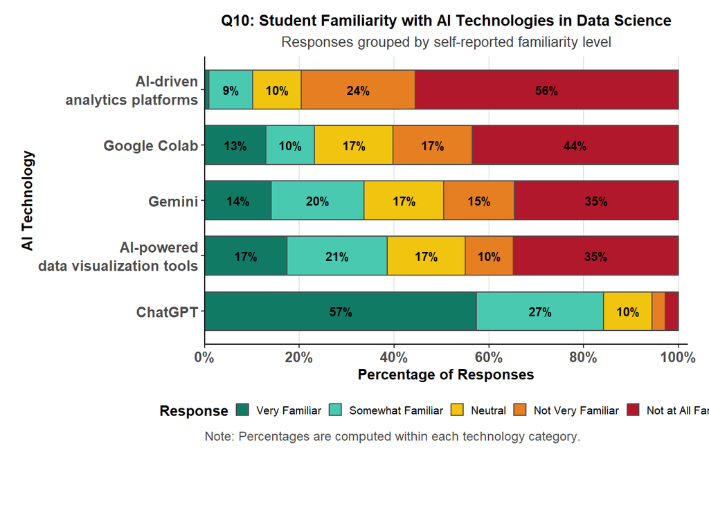

```r
library(ggplot2)
library(dplyr)
library(forcats)
library(scales)
library(tidyr)
library(grid)

# ---------------------------
# Shared Levels and Palette
# ---------------------------
levels_q10 <- c("Not at All Familiar", "Not Very Familiar", "Neutral", "Somewhat Familiar", "Very Familiar")

pal_q <- c(
  "Not at All Familiar" = "#B2182B",  # deep red (least familiar)
  "Not Very Familiar"   = "#E67E22",  # orange
  "Neutral"             = "#F1C40F",  # gold
  "Somewhat Familiar"   = "#48C9B0",  # turquoise
  "Very Familiar"       = "#117A65"   # deep teal (most familiar)
)
# --- 2️⃣ Labels and Levels ---
tech_map <- c(
  Q10_1 = "ChatGPT",
  Q10_2 = "Gemini",
  Q10_3 = "Google Colab",
  Q10_4 = "AI-powered\ndata visualization tools",
  Q10_5 = "AI-driven\nanalytics platforms"
)
# ---------------------------
# Data Preparation
# ---------------------------
df_long_q10 <- FilteredDF %>%
  pivot_longer(starts_with("Q10_"), names_to = "Item", values_to = "Response") %>%
  mutate(
    Technology = recode(Item, !!!tech_map, .default = NA_character_),
    Response   = factor(Response, levels = levels_q10)
  ) %>%
  filter(!is.na(Response), !is.na(Technology))

plot_df_q10 <- df_long_q10 %>%
  count(Technology, Response, .drop = FALSE) %>%
  group_by(Technology) %>%
  mutate(pct = n / sum(n)) %>%
  ungroup() %>%
  group_by(Technology) %>%
  mutate(pct_familiar = sum(pct[Response %in% c("Somewhat Familiar", "Very Familiar")], na.rm = TRUE)) %>%
  ungroup() %>%
  mutate(Technology = fct_reorder(Technology, pct_familiar, .desc = TRUE))

# ---------------------------
# Plot
# ---------------------------
p_q10 <- ggplot(plot_df_q10, aes(y = Technology, x = pct, fill = Response)) +
  geom_bar(stat = "identity", color = "gray30", width = 0.7) +

 # Optional: Add centered % labels inside bars (uncomment to use)
  geom_text(
    aes(label = ifelse(pct > 0.04, paste0(round(pct * 100), "%"), "")),
    position = position_stack(vjust = 0.5),
    color = "black", size = 3, fontface = "bold"
  ) +

  scale_x_continuous(
    labels = label_percent(accuracy = 1),
    limits = c(0, 1),
    breaks = seq(0, 1, 0.2),
    expand = expansion(mult = c(0, 0.02))
  ) +

  scale_fill_manual(values = pal_q, guide = guide_legend(reverse = TRUE)) +

  labs(
    title = "Q10: Student Familiarity with AI Technologies in Data Science",
    subtitle = "Responses grouped by self-reported familiarity level",
    x = "Percentage of Responses",
    y = "AI Technology",
    fill = "Response",
    caption = "Note: Percentages are computed within each technology category."
  ) +

  # ---------------------------
  # Enhanced Publication Theme
  # ---------------------------
  theme_classic(base_size = 10) +
  theme(
    plot.title      = element_text(face = "bold", size = 11, hjust = 0.5),
    plot.subtitle   = element_text(size = 10, hjust = 0.5, color = "gray25"),
    axis.text.x     = element_text(face = "bold", size = 10),
    axis.text.y     = element_text(face = "bold", size = 10, lineheight = 1.1),
    axis.title.x    = element_text(face = "bold", size = 10),
    axis.title.y    = element_text(face = "bold", size = 10),
    panel.grid.major.x = element_line(color = "gray90"),
    panel.grid.minor = element_blank(),
    legend.title    = element_text(face = "bold"),
    legend.text     = element_text(size = 8),
    legend.position = "bottom",
    legend.key.size = unit(0.35, "cm"),
    plot.caption    = element_text(size = 9, hjust = 0, color = "gray30"),
    plot.margin     = margin(10, 15, 45, 15)
  )

# ---------------------------
# Save High-Resolution Figure
# ---------------------------

print(p_q10)
```

```r
ggsave(
  filename = "Studnt_figs_10/Q10_familiarity_horizontal_fxd.png",
  plot = p_q10,
  dpi = 600,
  width = 9.5,
  height = 6.5,
  units = "in"
)
```

## Q10 revised

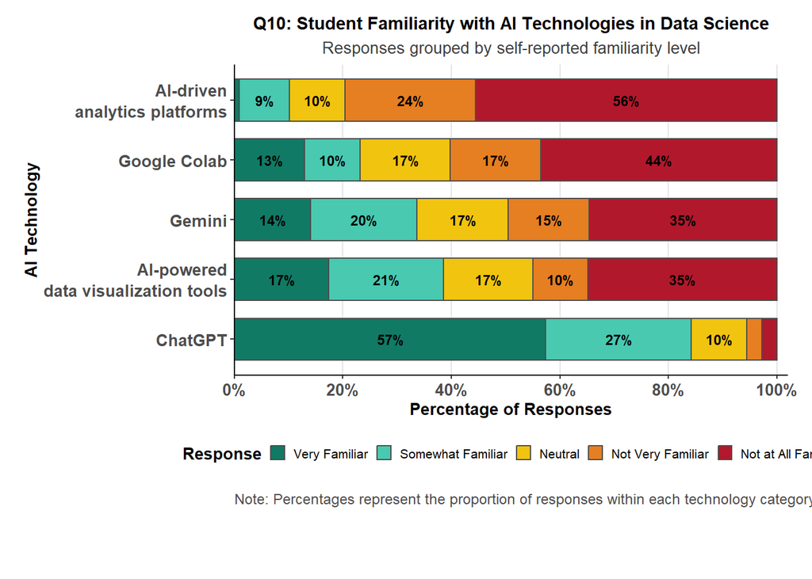

```r
p_q10 <- ggplot(plot_df_q10, aes(y = Technology, x = pct, fill = Response)) +
  geom_bar(stat = "identity", color = "gray30", width = 0.7) +
  geom_text(
    aes(label = ifelse(pct > 0.04, paste0(round(pct * 100), "%"), "")),
    position = position_stack(vjust = 0.5),
    color = "black", size = 3, fontface = "bold"
  ) +
  scale_x_continuous(
    labels = label_percent(accuracy = 1),
    limits = c(0, 1),
    breaks = seq(0, 1, 0.2),
    expand = expansion(mult = c(0, 0.02))
  ) +
  scale_fill_manual(values = pal_q, guide = guide_legend(reverse = TRUE)) +
  labs(
    title = "Q10: Student Familiarity with AI Technologies in Data Science",
    subtitle = "Responses grouped by self-reported familiarity level",
    x = "Percentage of Responses",
    y = "AI Technology",
    fill = "Response",
    caption = "Note: Percentages represent the proportion of responses within each technology category."
  ) +
  theme_pub()

##################

print(p_q10)
```

```r
ggsave(
  filename = "Studnt_figs_10/Q10_familiarity_horizontal_fxd.png",
  plot = p_q10,
  dpi = 700,
  width = 9.5,
  height = 6.5,  # slightly taller for legend space
  units = "in"
)
```

## Q11: Which AI tools have you used in your data science tasks? (Select all that apply) - Selected Choice

```r
# Step 0: Define the exact expected options (based on your survey config)
Q11_options <- c(
  "ChatGPT",
  "Grammarly",
  "Claude and Copilot",
  "AI-powered visualization tools",
  "Copilot",
  "Gemini",
  "Canva or AI assisted presentation tools",
  "Predictive analytics tools (e.g.DataRobot)",
  "None",
  "Others please specify"
)

# Step 1: Extract responses and clean
long_Q11 <- FilteredDF %>%
  select(Q11) %>%
  filter(!is.na(Q11))

# Step 2: Create a binary indicator for each known option
for (opt in Q11_options) {
  long_Q11[[opt]] <- str_detect(long_Q11$Q11, fixed(opt))
}

# Step 3: Convert wide to long and count
Q11_summary <- long_Q11 %>%
  pivot_longer(cols = all_of(Q11_options), names_to =   "Response", values_to = "Selected") %>%
  filter(Selected) %>%
  count(Response, sort = TRUE)
# View result
# Q 11 Which AI tools have you used in your data science tasks? (Select all that apply)
print(Q11_summary)
```

```
## # A tibble: 5 × 2
##   Response                                    n
##   <chr>                                   <int>
## 1 ChatGPT                                    88
## 2 Grammarly                                  59
## 3 Canva or AI assisted presentation tools    42
## 4 AI-powered visualization tools             29
## 5 None                                       11
```

```r
## With Percents
Q11_summary2 <- long_Q11 %>%
  count(Q11, sort = TRUE) %>%
  rename(Response = Q11, Frequency = n) %>%
  mutate(Relative_Freq = round(Frequency / 120*100, digits=1))

# View summary
print(Q11_summary2)
```

```
## # A tibble: 23 × 3
##    Response                                              Frequency Relative_Freq
##    <chr>                                                     <int>         <dbl>
##  1 ChatGPT                                                      23          19.2
##  2 ChatGPT ,Grammarly ,Canva or AI assisted presentatio…        18          15
##  3 ChatGPT ,Grammarly                                           13          10.8
##  4 ChatGPT ,AI-powered visualization tools ,Grammarly ,…        11           9.2
##  5 None                                                         11           9.2
##  6 ChatGPT ,AI-powered visualization tools                       6           5
##  7 ChatGPT ,Canva or AI assisted presentation tools              5           4.2
##  8 Grammarly                                                     4           3.3
##  9 ChatGPT ,AI-powered visualization tools ,Grammarly            3           2.5
## 10 AI-powered visualization tools ,Grammarly                     2           1.7
## # ℹ 13 more rows
```

```r
library(dplyr)
library(tidyr)
library(forcats)
library(ggplot2)
library(scales)
library(stringr)

# ---- 1) Define expected options ----
Q11_options <- c(
  "ChatGPT",
  "Grammarly",
  "Claude and Copilot",
  "AI-powered visualization tools",
  "Copilot",
  "Gemini",
  "Canva or AI-assisted \npresentation tools",
  "Predictive analytics tools",
  "None"
 # "Others please specify"
)

# ---- 2) Extract and clean responses ----
long_Q11 <- FilteredDF %>%
  select(Q11) %>%
  filter(!is.na(Q11))

# ---- 3) Create binary indicators for each tool ----
for (opt in Q11_options) {
  long_Q11[[opt]] <- str_detect(long_Q11$Q11, fixed(opt))
}

# ---- 4) Convert wide → long and summarize ----
 n_valid <- FilteredDF%>% filter(!is.na(Q11)) %>% nrow()


# ---- 4) Summarize counts and percentages ----
Q11_summary <- long_Q11 %>%
  pivot_longer(
    cols = all_of(Q11_options),
    names_to = "Tool",
    values_to = "Selected"
  ) %>%
  filter(Selected) %>%
  count(Tool, name = "Count") %>%
  mutate(
    Percent = Count / n_valid,
    Label = paste0(Count, " (", round(Percent * 100, 1), "%)")
  )

# ---- 5) Polished horizontal bar chart ----
p_q11 <- ggplot(Q11_summary, aes(
  y = fct_reorder(Tool, Percent),
  x = Percent
)) +
  geom_bar(stat = "identity", fill = "#48C9B0", color = "gray30", width = 0.7) +

  # Inline labels: counts + percents
  geom_text(
    aes(label = Label),
    hjust = -0.1, fontface = "bold", size = 3.6, color = "black"
  ) +

  # X-axis settings
  scale_x_continuous(
    labels = label_percent(accuracy = 1),
    limits = c(0, max(Q11_summary$Percent) + 0.1),
    expand = expansion(mult = c(0, 0.02))
  ) +

  # Titles and captions
  labs(
    title = "Q11: AI Tools Used in Data Science Tasks",
    subtitle = "Multiple selections allowed; percentages based on valid respondents",
    x = "Percentage of Respondents",
    y = "AI Tool",
    caption = paste0(
      "n = ", n_valid,
      " respondents (percentages may exceed 100% because multiple choices were allowed)."
    )
  ) +

  # Publication theme (consistent with your previous figures)
  theme_pub() +
  theme(
    panel.grid.major.y = element_blank(),
    axis.text.y = element_text(size = 10.5, lineheight = 1.1),
    plot.title = element_text(face = "bold", size = 14),
    plot.subtitle = element_text(size = 11),
    plot.caption = element_text(size = 9),
    plot.margin = margin(10, 25, 25, 15)
  )

# ---- 6) Optional: Save high-resolution figure ----
if (!dir.exists("Studnt_figs_10")) dir.create("Studnt_figs_10", recursive = TRUE)

ggsave(
  filename = "Studnt_figs_10/Q11_ai_tools.png",
  plot = p_q11,
  dpi = 600,
  width = 8.5,
  height = 5.5,
  units = "in"
)

# ---- 7) Display summary table ----
Q11_summary
```

```
## # A tibble: 5 × 4
##   Tool                           Count Percent Label
##   <chr>                          <int>   <dbl> <chr>
## 1 AI-powered visualization tools    29  0.264  29 (26.4%)
## 2 ChatGPT                           88  0.8    88 (80%)
## 3 Grammarly                         59  0.536  59 (53.6%)
## 4 None                              11  0.1    11 (10%)
## 5 Predictive analytics tools         5  0.0455 5 (4.5%)
```

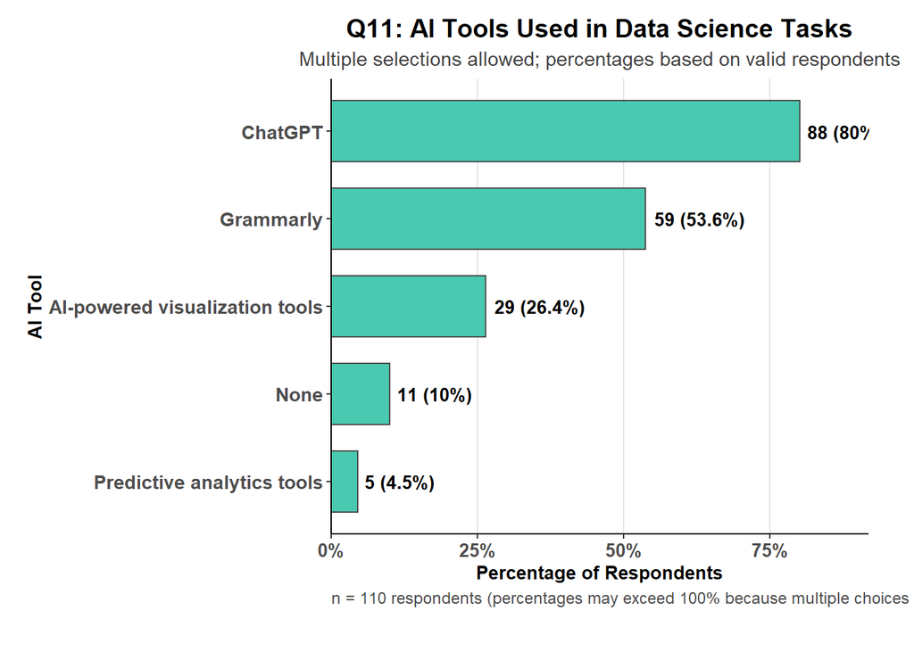

```r
print(p_q11)
```

```r
result_q7 <- plot_multi_response(
  data = FilteredDF,
  col = Q11,
  title = "Q11: AI Tools Used in Data Science Tasks",
  xlab = "Percentage of Respondents",
  ylab = "AI Tool"
)
```

```
## ✅ Plot saved as: Studnt_figs_10/Q11.png
```

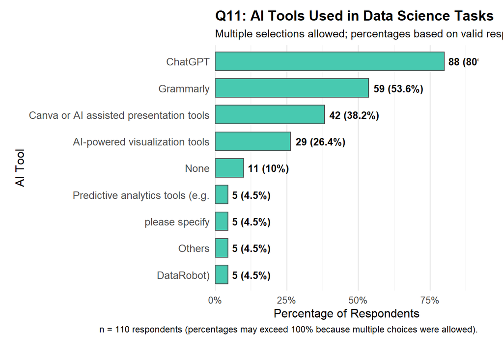

```
##
## $summary
## # A tibble: 9 × 4
##   Response                                Count Percent Label
##   <chr>                                   <int>   <dbl> <chr>
## 1 ChatGPT                                    88  0.8    88 (80%)
## 2 Grammarly                                  59  0.536  59 (53.6%)
## 3 Canva or AI assisted presentation tools    42  0.382  42 (38.2%)
## 4 AI-powered visualization tools             29  0.264  29 (26.4%)
## 5 None                                       11  0.1    11 (10%)
## 6 DataRobot)                                  5  0.0455 5 (4.5%)
## 7 Others                                      5  0.0455 5 (4.5%)
## 8 Predictive analytics tools (e.g.            5  0.0455 5 (4.5%)
## 9 please specify                              5  0.0455 5 (4.5%)
##
## $file
## [1] "Studnt_figs_10/Q11.png"
```

```r
print(result_q7)
```

## Q12_1: To what extent do you agree with the following statements regarding AI tools in data science?

## Q 12 Redone same format as 10

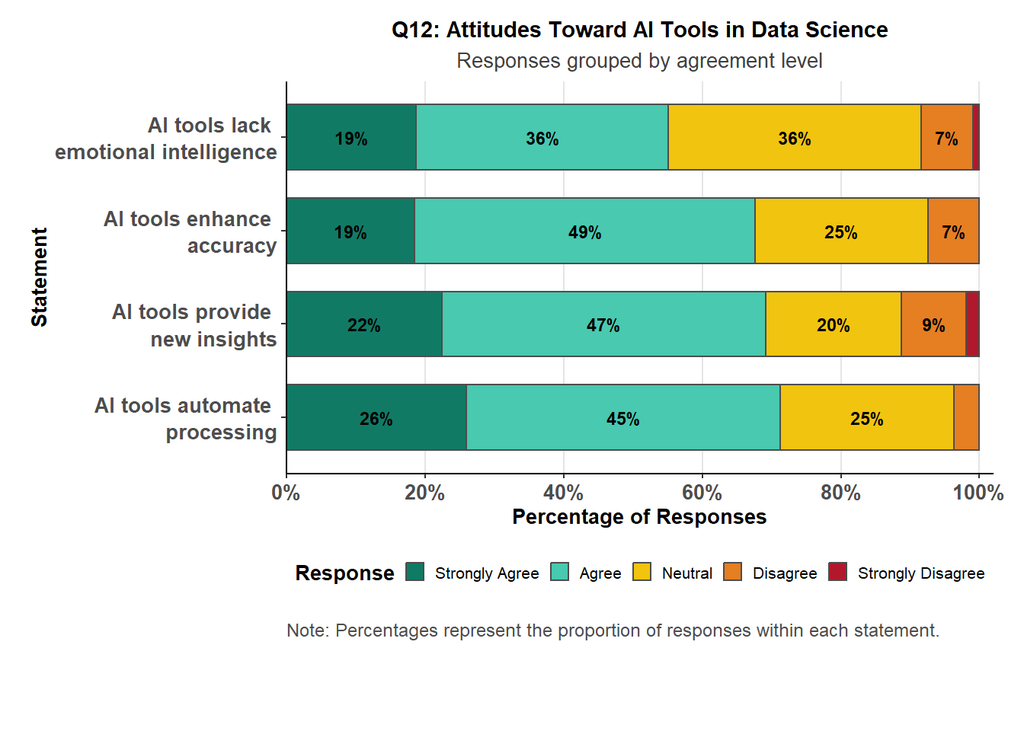

```r
# ---- 1) Map Q12_* to statement labels ----
statement_map <- c(
  Q12_1 = "AI tools enhance \naccuracy",
  Q12_2 = "AI tools automate \nprocessing",
  Q12_3 = "AI tools provide \nnew insights",
  Q12_4 = "AI tools lack \nemotional intelligence"
)

# ---- 2) Long format + recode ----
df_long_q12 <- FilteredDF %>%
  pivot_longer(
    cols = starts_with("Q12_"),
    names_to = "Item",
    values_to = "Response"
  ) %>%
  mutate(
    Statement = dplyr::recode(Item, !!!statement_map, .default = NA_character_),
    Response = factor(
      Response,
      levels = c("Strongly Disagree", "Disagree", "Neutral", "Agree", "Strongly Agree")
    )
  ) %>%
  filter(!is.na(Response), !is.na(Statement))

# ---- 3) Compute proportions per statement ----
plot_df_q12 <- df_long_q12 %>%
  count(Statement, Response, .drop = FALSE) %>%
  group_by(Statement) %>%
  mutate(pct = n / sum(n)) %>%
  ungroup()

# ---- 4) Order statements by % favorable (Agree + Strongly Agree) ----
plot_df_q12 <- plot_df_q12 %>%
  group_by(Statement) %>%
  mutate(pct_fav = sum(pct[Response %in% c("Agree", "Strongly Agree")], na.rm = TRUE)) %>%
  ungroup() %>%
  mutate(Statement = fct_reorder(Statement, pct_fav, .desc = TRUE))

# ---- 5) Custom palette (consistent with your red→green family) ----
pal_q12 <- c(
  "Strongly Disagree" = "#B2182B",
  "Disagree"          = "#E67E22",
  "Neutral"           = "#F1C40F",
  "Agree"             = "#48C9B0",
  "Strongly Agree"    = "#117A65"
)

# ---- 6) Horizontal stacked proportion bar chart ----
p_q12 <- ggplot(plot_df_q12, aes(y = Statement, x = pct, fill = Response)) +
  geom_bar(stat = "identity", color = "gray30", width = 0.7) +

  # Optional percentage labels
  geom_text(
    aes(label = ifelse(pct > 0.04, paste0(round(pct * 100), "%"), "")),
    position = position_stack(vjust = 0.5),
    color = "black", size = 3, fontface = "bold"
  ) +

  scale_x_continuous(
    labels = label_percent(accuracy = 1),
    limits = c(0, 1),
    breaks = seq(0, 1, 0.2),
    expand = expansion(mult = c(0, 0.02))
  ) +
  scale_fill_manual(values = pal_q12, guide = guide_legend(reverse = TRUE)) +

  labs(
    title = "Q12: Attitudes Toward AI Tools in Data Science",
    subtitle = "Responses grouped by agreement level",
    x = "Percentage of Responses",
    y = "Statement",
    fill = "Response",
    caption = "Note: Percentages represent the proportion of responses within each statement."
  ) +

  # Apply your saved publication theme
  theme_pub()

# ---- 7) Save High-Resolution Figure ----
ggsave(
  filename = "Studnt_figs_10/Q12_attitudes_horizontal_pub.pdf",
  plot = p_q12,
  dpi = 600,
  width = 9,
  height = 6,
  units = "in"
)

print(p_q12)
```

## Q13: “How often do you use AI tools for the following data science tasks? (Never, Rarely, Sometimes, Often, Always)”

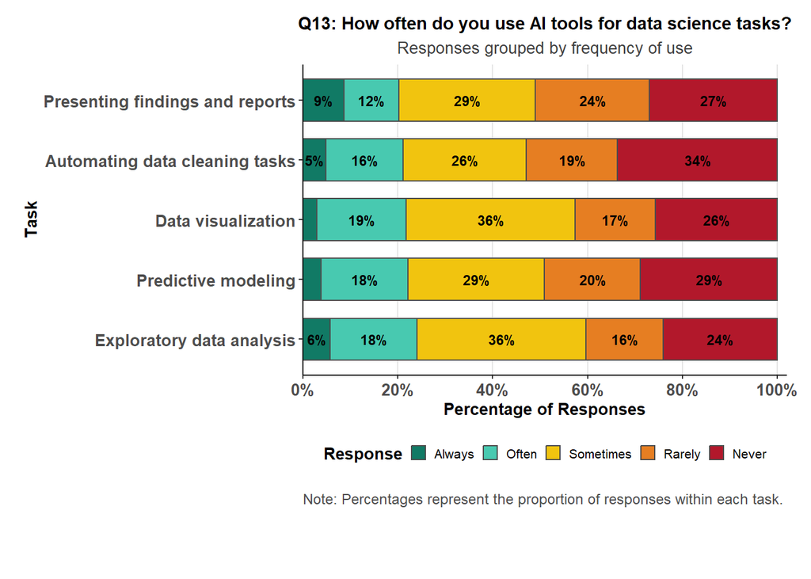

```r
# ---- 1) Map Q13_* to task labels ----
task_map <- c(
  Q13_1 = "Exploratory data analysis",
  Q13_2 = "Predictive modeling",
  Q13_3 = "Data visualization",
  Q13_4 = "Automating data cleaning tasks",
  Q13_5 = "Presenting findings and reports"
)

# ---- 2) Define levels + consistent palette ----
levels_q13 <- c("Never", "Rarely", "Sometimes", "Often", "Always")
pal_q13 <- c(
  "Never"     = "#B2182B",  # red
  "Rarely"    = "#E67E22",  # orange
  "Sometimes" = "#F1C40F",  # gold
  "Often"     = "#48C9B0",  # turquoise
  "Always"    = "#117A65"   # teal green
)

# ---- 3) Reshape and clean ----
df_long_q13 <- FilteredDF %>%
  pivot_longer(
    cols = starts_with("Q13_"),
    names_to = "Item",
    values_to = "Response"
  ) %>%
  mutate(
    Task     = recode(Item, !!!task_map, .default = NA_character_),
    Response = factor(Response, levels = levels_q13)
  ) %>%
  filter(!is.na(Response), !is.na(Task))

# ---- 4) Calculate proportions ----
plot_df_q13 <- df_long_q13 %>%
  count(Task, Response, .drop = FALSE) %>%
  group_by(Task) %>%
  mutate(pct = n / sum(n)) %>%
  ungroup()

# ---- 5) Order tasks by % high use (Often + Always) ----
plot_df_q13 <- plot_df_q13 %>%
  group_by(Task) %>%
  mutate(pct_high = sum(pct[Response %in% c("Often", "Always")], na.rm = TRUE)) %>%
  ungroup() %>%
  mutate(Task = fct_reorder(Task, pct_high, .desc = TRUE))

# ---- 6) Horizontal stacked bar chart ----
p_q13 <- ggplot(plot_df_q13, aes(y = Task, x = pct, fill = Response)) +
  geom_bar(stat = "identity", color = "gray30", width = 0.7) +

  # Optional: add centered % labels inside bars
  geom_text(
    aes(label = ifelse(pct > 0.04, paste0(round(pct * 100), "%"), "")),
    position = position_stack(vjust = 0.5),
    color = "black", size = 3, fontface = "bold"
  ) +

  scale_x_continuous(
    labels = label_percent(accuracy = 1),
    limits = c(0, 1),
    breaks = seq(0, 1, 0.2),
    expand = expansion(mult = c(0, 0.02))
  ) +

  scale_fill_manual(values = pal_q13, guide = guide_legend(reverse = TRUE)) +

  labs(
    title = "Q13: How often do you use AI tools for data science tasks?",
    subtitle = "Responses grouped by frequency of use",
    x = "Percentage of Responses",
    y = "Task",
    fill = "Response",
    caption = "Note: Percentages represent the proportion of responses within each task."
  ) +

  # Apply your publication theme (legend below plot)
  theme_pub()

# ---- 7) Save high-resolution figure ----
ggsave(
  filename = "Studnt_figs_10/Q13_utilization_horizontal_pub.pdf",
  plot = p_q13,
  dpi = 600,
  width = 9,
  height = 6,
  units = "in"
)

print(p_q13)
```

## Q14: How confident are you in explaining AI-generated outputs for data analysis tasks to peers or supervisors?

```r
FilteredDF$Q14 <- factor(FilteredDF$Q14,
  levels = c("Very Confident", "Confident", "Neutral",
             "Not Very Confident", "Not at All Confident"))

# Frequency table
FilteredDF %>%
  filter(!is.na(Q14)) %>%
  tabyl(Q14)
```

```
##                   Q14  n    percent
##        Very Confident 11 0.10377358
##             Confident 32 0.30188679
##               Neutral 31 0.29245283
##    Not Very Confident 23 0.21698113
##  Not at All Confident  9 0.08490566
```

## Stopped at Q14 redoo he rst using same color style and switch to horizontal charts

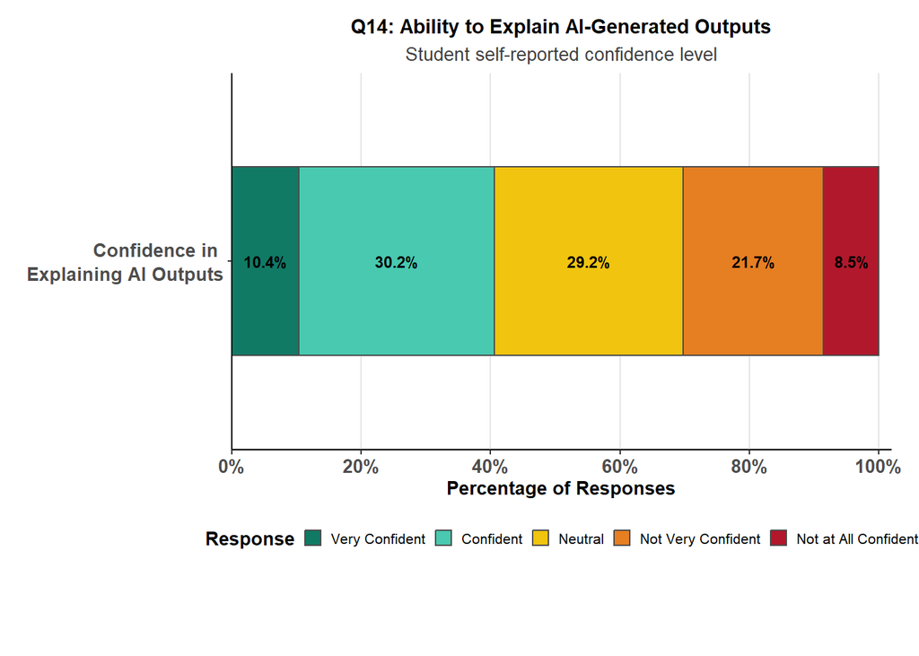

```r
# ---- 1) Factor order and consistent color palette ----
conf_levels <- c(
  "Not at All Confident",
  "Not Very Confident",
  "Neutral",
  "Confident",
  "Very Confident"
)

conf_colors <- c(
  "Not at All Confident" = "#B2182B",  # deep red
  "Not Very Confident"   = "#E67E22",  # orange
  "Neutral"              = "#F1C40F",  # gold
  "Confident"            = "#48C9B0",  # turquoise
  "Very Confident"       = "#117A65"   # teal green
)

# ---- 2) Prepare data: counts + percentages ----
plot_df_q14 <- FilteredDF %>%
  filter(!is.na(Q14)) %>%
  mutate(Response = factor(Q14, levels = conf_levels)) %>%
  count(Response, .drop = FALSE) %>%
  mutate(
    pct   = n / sum(n),
    label = scales::percent(pct, accuracy = 0.1)
  )

# ---- 3) Horizontal 100% stacked bar with percentage labels ----
p_q14 <- ggplot(plot_df_q14,
                aes(y = "Confidence in \nExplaining AI Outputs", x = pct, fill = Response)) +
  geom_col(width = 0.6, color = "gray30") +

  # Percent labels inside segments (only for larger segments)
  geom_text(
    aes(label = ifelse(pct >= 0.03, label, "")),
    position = position_stack(vjust = 0.5),
    size = 3, fontface = "bold", color = "black"
  ) +

  # X-axis in percentage format
  scale_x_continuous(
    labels = label_percent(accuracy = 1),
    limits = c(0, 1),
    breaks = seq(0, 1, 0.2),
    expand = expansion(mult = c(0, 0.02))
  ) +

  # Reverse legend order to show “Very Confident” first
  scale_fill_manual(values = conf_colors, guide = guide_legend(reverse = TRUE)) +

  # Titles, labels, caption
  labs(
    title = "Q14: Ability to Explain AI-Generated Outputs",
    subtitle = "Student self-reported confidence level",
    x = "Percentage of Responses",
    y = NULL,
    fill = "Response",
#    caption = "Note: Percentages represent the proportion of respondents selecting each confidence level."
  ) +

  # Apply publication theme (legend under plot)
  theme_pub()

# ---- 4) Save high-resolution figure ----
ggsave(
  filename = "Studnt_figs_10/Q14_explainability_horizontal_pub.pdf",
  plot = p_q14,
  dpi = 600,
  width = 8.5,
  height = 4.5,   # slightly taller to fit legend
  units = "in"
)

print(p_q14)
```

## Q15: To what extent do you agree with the following statements regarding the future of AI in data science? (Strongly Disagree, Disagree, Neutral, Agree, Strongly Agree)

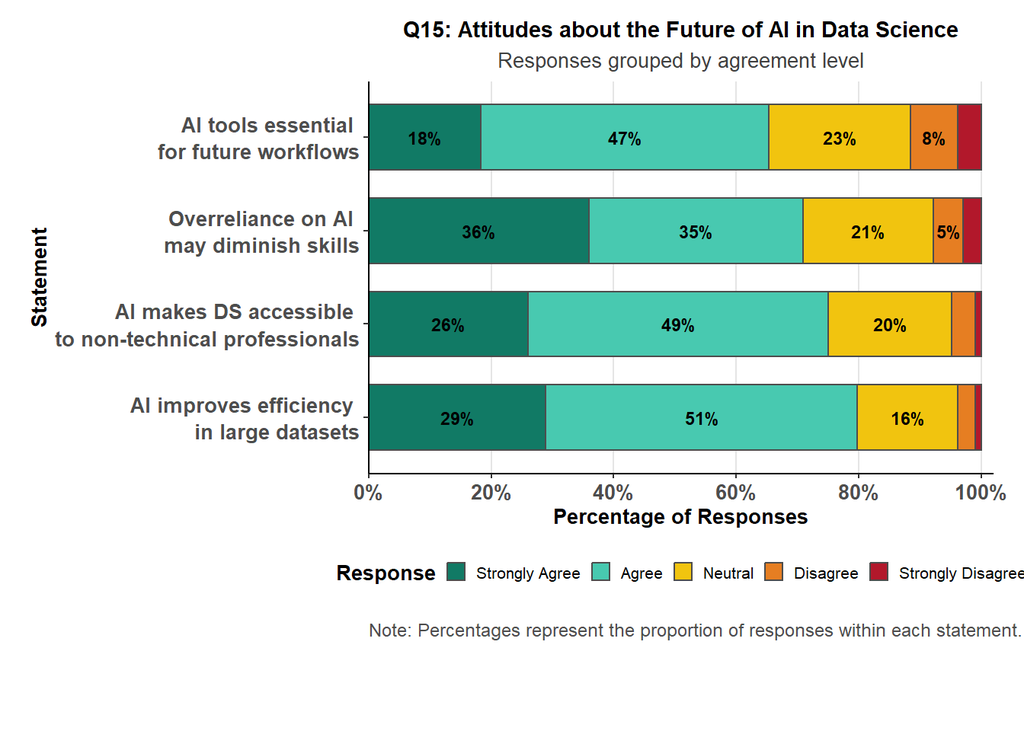

```r
# ---- 1) Define recode map and consistent palette ----
statement_map_q15 <- c(
  Q15_1 = "AI tools essential \nfor future workflows",
  Q15_2 = "AI improves efficiency \nin large datasets",
  Q15_3 = "AI makes DS accessible \nto non-technical professionals",
  Q15_4 = "Overreliance on AI \nmay diminish skills"
)

levels_q15 <- c("Strongly Disagree", "Disagree", "Neutral", "Agree", "Strongly Agree")
pal_q15 <- c(
  "Strongly Disagree" = "#B2182B",  # deep red
  "Disagree"          = "#E67E22",  # orange
  "Neutral"           = "#F1C40F",  # gold
  "Agree"             = "#48C9B0",  # turquoise
  "Strongly Agree"    = "#117A65"   # teal green
)

# ---- 2) Reshape and clean ----
df_long_q15 <- FilteredDF %>%
  pivot_longer(
    cols = starts_with("Q15_"),
    names_to = "Item",
    values_to = "Response"
  ) %>%
  mutate(
    Statement = recode(Item, !!!statement_map_q15, .default = NA_character_),
    Response  = factor(Response, levels = levels_q15)
  ) %>%
  filter(!is.na(Response), !is.na(Statement))

# ---- 3) Calculate proportions ----
plot_df_q15 <- df_long_q15 %>%
  count(Statement, Response, .drop = FALSE) %>%
  group_by(Statement) %>%
  mutate(pct = n / sum(n)) %>%
  ungroup() %>%
  group_by(Statement) %>%
  mutate(pct_agree = sum(pct[Response %in% c("Agree", "Strongly Agree")], na.rm = TRUE)) %>%
  ungroup() %>%
  mutate(Statement = fct_reorder(Statement, pct_agree, .desc = TRUE))

# ---- 4) Horizontal stacked bar chart ----
p_q15 <- ggplot(plot_df_q15, aes(y = Statement, x = pct, fill = Response)) +
  geom_bar(stat = "identity", color = "gray30", width = 0.7) +

  # Optional percentage labels
  geom_text(
    aes(label = ifelse(pct > 0.04, paste0(round(pct * 100), "%"), "")),
    position = position_stack(vjust = 0.5),
    color = "black", size = 3, fontface = "bold"
  ) +

  scale_x_continuous(
    labels = label_percent(accuracy = 1),
    limits = c(0, 1),
    breaks = seq(0, 1, 0.2),
    expand = expansion(mult = c(0, 0.02))
  ) +
  scale_fill_manual(values = pal_q15, guide = guide_legend(reverse = TRUE)) +

  labs(
    title = "Q15: Attitudes about the Future of AI in Data Science",
    subtitle = "Responses grouped by agreement level",
    x = "Percentage of Responses",
    y = "Statement",
    fill = "Response",
    caption = "Note: Percentages represent the proportion of responses within each statement."
  ) +

  # Apply your saved publication theme (with bottom legend)
  theme_pub()

# ---- 5) Save as high-resolution PNG ----
ggsave(
  filename = "Studnt_figs_10/Q15_attitudes_horizontal_pub.png",
  plot = p_q15,
  dpi = 600,
  width = 9,
  height = 6,
  units = "in"
)

print(p_q15)
```

## Q16: Do you think students should learn how to use AI tools for their data science careers?

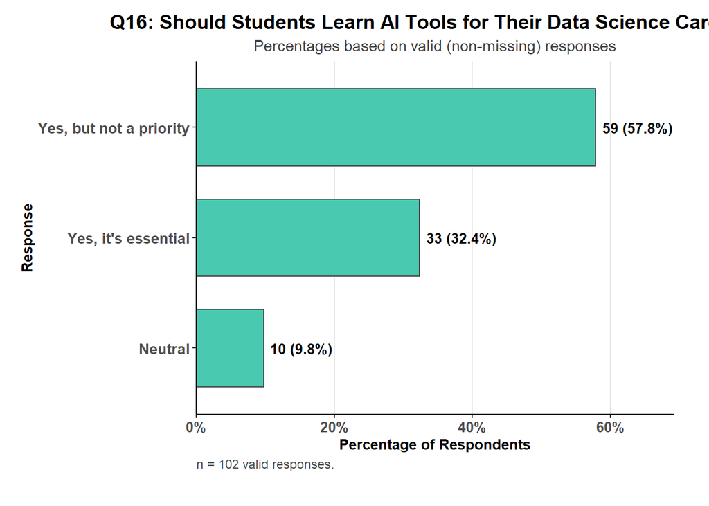

```r
library(dplyr)
library(ggplot2)
library(forcats)
library(scales)
library(janitor)

# ---- 1) Define ordered factor levels ----
FilteredDF$Q16 <- factor(FilteredDF$Q16,
  levels = c(
    "Yes, it's essential",
    "Yes, but not a priority",
    "Neutral",
    "No, it's not necessary",
    "No, it may even be harmful"
  )
)

# ---- 2) Compute frequencies and percentages ----
n_valid <- FilteredDF %>% filter(!is.na(Q16)) %>% nrow()

plot_df_q16 <- FilteredDF %>%
  filter(!is.na(Q16)) %>%
  count(Q16, name = "Count") %>%
  mutate(
    Percent = Count / n_valid,
    Label = paste0(Count, " (", round(Percent * 100, 1), "%)")
  )

# ---- 3) Horizontal bar chart (publication style) ----
p_q16 <- ggplot(plot_df_q16, aes(
  y = fct_reorder(Q16, Percent),
  x = Percent
)) +
  geom_bar(stat = "identity", fill = "#48C9B0", color = "gray30", width = 0.7) +

  # Inline count + percent labels
  geom_text(
    aes(label = Label),
    hjust = -0.1, fontface = "bold", size = 3.6, color = "black"
  ) +

  # X-axis formatting
  scale_x_continuous(
    labels = label_percent(accuracy = 1),
    limits = c(0, max(plot_df_q16$Percent) + 0.1),
    expand = expansion(mult = c(0, 0.02))
  ) +

  # Titles and captions
  labs(
    title = "Q16: Should Students Learn AI Tools for Their Data Science Careers?",
    subtitle = "Percentages based on valid (non-missing) responses",
    x = "Percentage of Respondents",
    y = "Response",
    caption = paste0("n = ", n_valid, " valid responses.")
  ) +

  # Unified publication theme
  theme_pub() +
  theme(
    panel.grid.major.y = element_blank(),
    axis.text.y = element_text(size = 10.5, lineheight = 1.1),
    plot.title = element_text(face = "bold", size = 14),
    plot.subtitle = element_text(size = 11),
    plot.caption = element_text(size = 9),
    plot.margin = margin(10, 25, 25, 15)
  )

# ---- 4) Save high-resolution plot ----
if (!dir.exists("Studnt_figs_10")) dir.create("Studnt_figs_10", recursive = TRUE)

ggsave(
  filename = "Studnt_figs_10/Q16_ai_learning_importance_horizontal_pub.png",
  plot = p_q16,
  dpi = 600,
  width = 8.5,
  height = 5.5,
  units = "in"
)

# ---- 5) View table and plot ----
print(p_q16)
```

```r
plot_df_q16
```

```
## # A tibble: 3 × 4
##   Q16                     Count Percent Label
##   <fct>                   <int>   <dbl> <chr>
## 1 Yes, it's essential        33  0.324  33 (32.4%)
## 2 Yes, but not a priority    59  0.578  59 (57.8%)
## 3 Neutral                    10  0.0980 10 (9.8%)
```

## Q17: To what extent do you agree with the following statement: I am willing to incorporate AI tools more into my data science projects in the future.

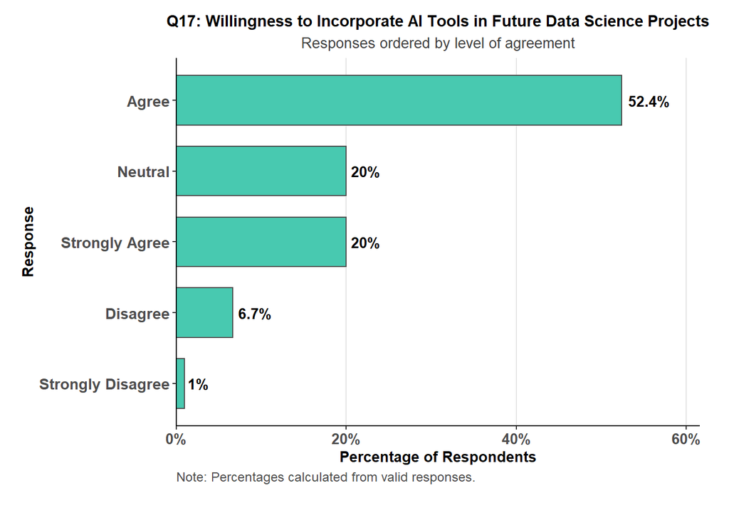

```r
library(dplyr)
library(ggplot2)
library(forcats)
library(scales)
library(janitor)

# ---- 1) Define factor order ----
FilteredDF$Q17 <- factor(FilteredDF$Q17,
  levels = c("Strongly Agree", "Agree", "Neutral", "Disagree", "Strongly Disagree")
)

# ---- 2) Compute frequency and percentages ----
plot_df_q17 <- FilteredDF %>%
  filter(!is.na(Q17)) %>%
  count(Q17) %>%
  mutate(Percent = n / sum(n))

# ---- 3) Horizontal bar chart with unified publication theme ----
p_q17 <- ggplot(plot_df_q17, aes(y = fct_reorder(Q17, Percent), x = Percent)) +
  geom_bar(stat = "identity", fill = "#48C9B0", color = "gray30", width = 0.7) +

  # Inline percentage labels
  geom_text(
    aes(label = paste0(round(Percent * 100, 1), "%")),
    hjust = -0.15, fontface = "bold", size = 3.6, color = "black"
  ) +

  # X-axis formatting
  scale_x_continuous(
    labels = label_percent(accuracy = 1),
    limits = c(0, max(plot_df_q17$Percent) + 0.08),
    breaks = seq(0, 1, 0.2),
    expand = expansion(mult = c(0, 0.02))
  ) +

  # Titles and labels
  labs(
    title = "Q17: Willingness to Incorporate AI Tools in Future Data Science Projects",
    subtitle = "Responses ordered by level of agreement",
    x = "Percentage of Respondents",
    y = "Response",
    caption = "Note: Percentages calculated from valid responses."
  ) +

  # Apply your shared publication theme
  theme_pub() +
  theme(
    panel.grid.major.y = element_blank(),
    axis.text.y = element_text(size = 10.5, lineheight = 1.1),
    plot.margin = margin(10, 20, 25, 15)
  )

# ---- 4) Save as high-resolution PNG ----
ggsave(
  filename = "Studnt_figs_10/Q17_integration_horizontal.png",
  plot = p_q17,
  dpi = 600,
  width = 8.5,
  height = 5.5,
  units = "in"
)

print(p_q17)
```

## Q17 updated

```r
result_Q17 <- plot_multi_response(
  data = FilteredDF,
  col = Q17,
  title = "Q17: Willingness to Incorporate AI Tools into DS Projects",
  xlab = "Percentage of Respondents",
  ylab = "Response"
)
```

```
## ✅ Plot saved as: Studnt_figs_10/Q17.png
```

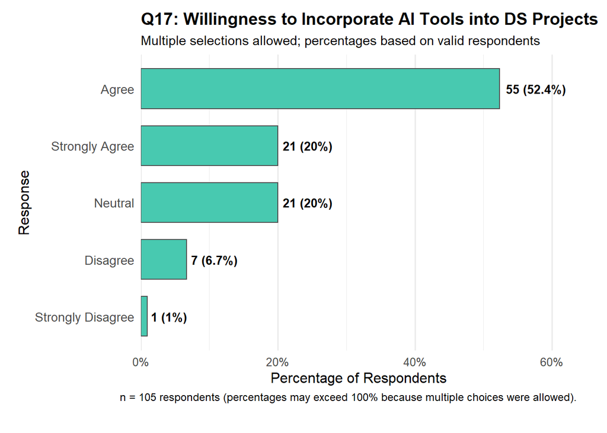

```r
# Display the plot
result_Q17$plot
```

```r
# View the summary table
  print(result_Q17$summary)
```

```
## # A tibble: 5 × 4
##   Response          Count Percent Label
##   <chr>             <int>   <dbl> <chr>
## 1 Agree                55 0.524   55 (52.4%)
## 2 Neutral              21 0.2     21 (20%)
## 3 Strongly Agree       21 0.2     21 (20%)
## 4 Disagree              7 0.0667  7 (6.7%)
## 5 Strongly Disagree     1 0.00952 1 (1%)
```

## Q18: To what extent are you aware of the following limitations of using AI for data science tasks? (Very Aware, Somewhat Aware, Neutral, Not Very Aware, Not at All Aware)

```r
# # Reshape Q18 into long format
# df_Q18 <- FilteredDF %>%
#   pivot_longer(cols = starts_with("Q18_"),
#                names_to = "Limitation",
#                values_to = "Response") %>%
#   mutate(
#     Response = factor(Response,
#                       levels = c("Very Aware", "Somewhat Aware", "Neutral",
#                                  "Not Very Aware", "Not at All Aware")),
#     Limitation = fct_recode(Limitation,
#       "AI tools produce biased results" = "Q18_1",
#       "AI tools generate factually incorrect outputs" = "Q18_2",
#       "AI models lack real-world experience/context" = "Q18_3",
#       "AI results need validation by experts" = "Q18_4",
#       "AI tools pose data privacy risks" = "Q18_5"
#     )
#   )
#
# # Frequency table
# df_Q18 %>%
#   filter(!is.na(Response)) %>%
#   count(Limitation, Response) %>%
#   group_by(Limitation) %>%
#   mutate(Percent = round(n / sum(n) * 100, 1))
#
```

## Q18 horizontal

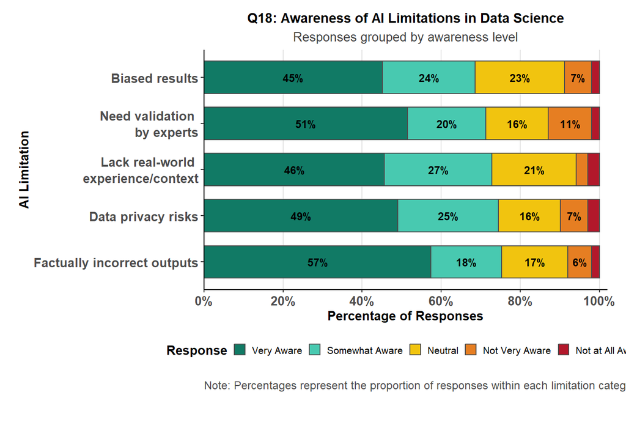

```r
# ---- 1) Define recode map ----
limitation_map <- c(
  Q18_1 = "Biased results",
  Q18_2 = "Factually incorrect outputs",
  Q18_3 = "Lack real-world \nexperience/context",
  Q18_4 = "Need validation \nby experts",
  Q18_5 = "Data privacy risks"
)

# ---- 2) Define factor levels + consistent palette ----
levels_q18 <- c(
  "Not at All Aware",
  "Not Very Aware",
  "Neutral",
  "Somewhat Aware",
  "Very Aware"
)

pal_q18 <- c(
  "Not at All Aware" = "#B2182B",  # deep red
  "Not Very Aware"   = "#E67E22",  # orange
  "Neutral"          = "#F1C40F",  # gold
  "Somewhat Aware"   = "#48C9B0",  # turquoise
  "Very Aware"       = "#117A65"   # teal green
)

# ---- 3) Reshape and clean ----
df_long_q18 <- FilteredDF %>%
  pivot_longer(
    cols = starts_with("Q18_"),
    names_to = "Item",
    values_to = "Response"
  ) %>%
  mutate(
    Limitation = recode(Item, !!!limitation_map, .default = NA_character_),
    Response   = factor(Response, levels = levels_q18)
  ) %>%
  filter(!is.na(Response), !is.na(Limitation))

# ---- 4) Calculate proportions ----
plot_df_q18 <- df_long_q18 %>%
  count(Limitation, Response, .drop = FALSE) %>%
  group_by(Limitation) %>%
  mutate(pct = n / sum(n)) %>%
  ungroup()

# ---- 5) Order by % high awareness (Somewhat + Very Aware) ----
plot_df_q18 <- plot_df_q18 %>%
  group_by(Limitation) %>%
  mutate(pct_high = sum(pct[Response %in% c("Somewhat Aware","Very Aware")], na.rm = TRUE)) %>%
  ungroup() %>%
  mutate(Limitation = fct_reorder(Limitation, pct_high, .desc = TRUE))

# ---- 6) Horizontal stacked bar chart ----
p_q18 <- ggplot(plot_df_q18, aes(y = Limitation, x = pct, fill = Response)) +
  geom_bar(stat = "identity", color = "gray30", width = 0.7) +

  # Optional percentage labels
  geom_text(
    aes(label = ifelse(pct > 0.04, paste0(round(pct * 100), "%"), "")),
    position = position_stack(vjust = 0.5),
    color = "black", size = 3, fontface = "bold"
  ) +

  scale_x_continuous(
    labels = label_percent(accuracy = 1),
    limits = c(0, 1),
    breaks = seq(0, 1, 0.2),
    expand = expansion(mult = c(0, 0.02))
  ) +
  scale_fill_manual(values = pal_q18, guide = guide_legend(reverse = TRUE)) +

  labs(
    title = "Q18: Awareness of AI Limitations in Data Science",
    subtitle = "Responses grouped by awareness level",
    x = "Percentage of Responses",
    y = "AI Limitation",
    fill = "Response",
    caption = "Note: Percentages represent the proportion of responses within each limitation category."
  ) +

  # Apply your saved publication theme
  theme_pub()

# ---- 7) Save as high-resolution PNG ----
ggsave(
  filename = "Studnt_figs_10/Q18_awareness_horizontal_pub.png",
  plot = p_q18,
  dpi = 600,
  width = 9,
  height = 6,
  units = "in"
)

print(p_q18)
```

## Q19: What are your primary concerns about using AI tools in data science?

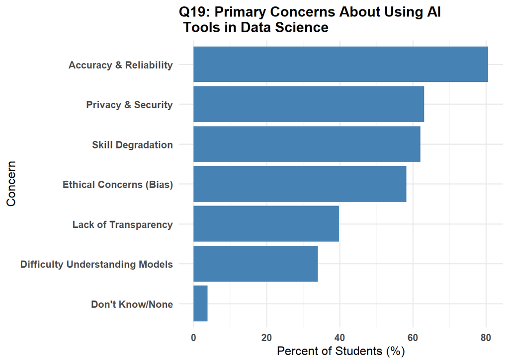

```r
library(stringr)
# Create new variables (binary indicators) for each concern
FilteredDF <- FilteredDF %>%
  mutate( concern_accuracy = str_detect(Q19, regex("accuracy", ignore_case = TRUE)), concern_transparency = str_detect(Q19, regex("transparency", ignore_case = TRUE)), concern_privacy = str_detect(Q19, regex("privacy", ignore_case = TRUE)), concern_ethics = str_detect(Q19, regex("ethic|bias", ignore_case = TRUE)), concern_skill_loss = str_detect(Q19, regex("skill", ignore_case = TRUE)), concern_understanding = str_detect(Q19, regex("understanding", ignore_case = TRUE)),
concern_none = str_detect(Q19, regex("don't|none", ignore_case = TRUE)) )
# Count totals for each concern
q19_summary <- tibble( Concern = c("Accuracy & Reliability", "Lack of Transparency", "Privacy & Security", "Ethical Concerns (Bias)", "Skill Degradation", "Difficulty Understanding Models", "Don't Know/None"),
                       Count = c( sum(FilteredDF$concern_accuracy, na.rm = TRUE), sum(FilteredDF$concern_transparency, na.rm = TRUE), sum(FilteredDF$concern_privacy, na.rm = TRUE), sum(FilteredDF$concern_ethics, na.rm = TRUE), sum(FilteredDF$concern_skill_loss, na.rm = TRUE), sum(FilteredDF$concern_understanding, na.rm = TRUE), sum(FilteredDF$concern_none, na.rm = TRUE) ) )
# Add percentages

n_valid <- FilteredDF %>% filter(!is.na(Q19)) %>% nrow()
q19_summary <- q19_summary %>% mutate(Percent = round(Count / n_valid * 100, 1))
# Show summary table q19_summary
# Bar chart
p_q19 <-ggplot(q19_summary,
                         aes(x = fct_reorder(Concern, Count),
                             y = Percent)) +
  geom_bar(stat = "identity", fill = "steelblue") +
  coord_flip() +
  ggtitle("Q19: Primary Concerns About Using AI \n Tools in Data Science") +
  xlab("Concern") +
  ylab("Percent of Students (%)") +
  theme_minimal(base_size = 12) +
  theme( axis.text.y = element_text(face = "bold"),
         axis.text.x = element_text(face = "bold"),
         plot.title = element_text(face = "bold", size = 14), legend.title= element_text(face = "bold") )
print(p_q19)
```

```r
# ---- 7) Save as rectangular figure ----
ggsave("Studnt_figs_10/Q19_Primary_Concerns.pdf", plot = p_q19, width = 8.5, height = 5.5, units = "in")
```

## Q19 redo

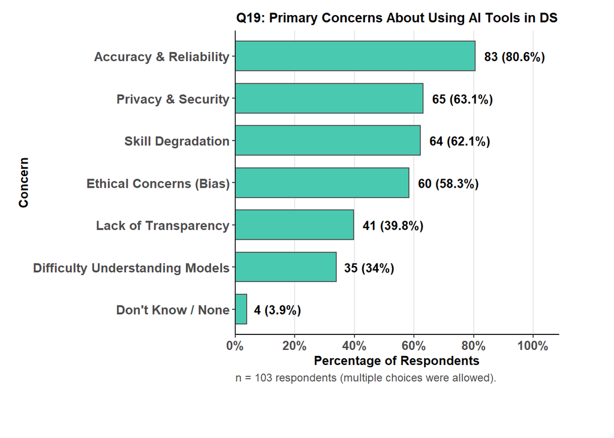

```r
library(dplyr)
library(forcats)
library(ggplot2)
library(scales)
library(stringr)
library(tibble)
library(stringr)
# Create new variables (binary indicators) for each concern
FilteredDF <- FilteredDF %>%
  mutate( concern_accuracy = str_detect(Q19, regex("accuracy", ignore_case = TRUE)), concern_transparency = str_detect(Q19, regex("transparency", ignore_case = TRUE)), concern_privacy = str_detect(Q19, regex("privacy", ignore_case = TRUE)), concern_ethics = str_detect(Q19, regex("ethic|bias", ignore_case = TRUE)), concern_skill_loss = str_detect(Q19, regex("skill", ignore_case = TRUE)), concern_understanding = str_detect(Q19, regex("understanding", ignore_case = TRUE)),
concern_none = str_detect(Q19, regex("don't|none", ignore_case = TRUE)) )
# Count totals for each concern
q19_summary <- tibble( Concern = c("Accuracy & Reliability", "Lack of Transparency", "Privacy & Security", "Ethical Concerns (Bias)", "Skill Degradation", "Difficulty Understanding Models", "Don't Know/None"),
                       Count = c( sum(FilteredDF$concern_accuracy, na.rm = TRUE), sum(FilteredDF$concern_transparency, na.rm = TRUE), sum(FilteredDF$concern_privacy, na.rm = TRUE), sum(FilteredDF$concern_ethics, na.rm = TRUE), sum(FilteredDF$concern_skill_loss, na.rm = TRUE), sum(FilteredDF$concern_understanding, na.rm = TRUE), sum(FilteredDF$concern_none, na.rm = TRUE) ) )
# Add percentages




n_valid <- FilteredDF %>% filter(!is.na(Q19)) %>% nrow()
q19_summary <- q19_summary %>% mutate(Percent = round(Count / n_valid * 100, 1))
# ---- 2) Summarize + add percentages ----
q19_summary <- tibble(
  Concern = c("Accuracy & Reliability",
              "Lack of Transparency",
              "Privacy & Security",
              "Ethical Concerns (Bias)",
              "Skill Degradation",
              "Difficulty Understanding Models",
              "Don't Know / None"),
  Count = c(
    sum(FilteredDF$concern_accuracy, na.rm = TRUE),
    sum(FilteredDF$concern_transparency, na.rm = TRUE),
    sum(FilteredDF$concern_privacy, na.rm = TRUE),
    sum(FilteredDF$concern_ethics, na.rm = TRUE),
    sum(FilteredDF$concern_skill_loss, na.rm = TRUE),
    sum(FilteredDF$concern_understanding, na.rm = TRUE),
    sum(FilteredDF$concern_none, na.rm = TRUE)
  )
) %>%
  mutate(Percent = Count / n_valid)

# ---- 3) Polished horizontal bar chart ----
p_q19 <- ggplot(q19_summary, aes(y = fct_reorder(Concern, Percent), x = Percent)) +
  geom_bar(stat = "identity", fill = "#48C9B0", color = "gray30", width = 0.7) +

  # Inline % labels
  geom_text(
    aes(label = paste0(Count, " (", round(Percent * 100, 1), "%)")),
    hjust = -0.15, size = 3.6, fontface = "bold", color = "black"
  ) +

  # Axes formatting
  scale_x_continuous(
    labels = label_percent(accuracy = 1),
    limits = c(0, max(q19_summary$Percent) + 0.250),
    breaks = seq(0, 1, 0.2),
    expand = expansion(mult = c(0, 0.03))
  ) +

  # Titles and caption
  labs(
    title = "Q19: Primary Concerns About Using AI Tools in DS",
  #  subtitle = "Top issues mentioned by respondents",
    x = "Percentage of Respondents",
    y = "Concern",
     caption = paste0("n = ", n_valid,
       " respondents (multiple choices were allowed).")
  ) +

  # Unified publication theme
  theme_pub() +
  theme(
    panel.grid.major.y = element_blank(),
    axis.text.y = element_text(size = 10.5, lineheight = 1.1),
    plot.margin = margin(10, 45, 45, 15)
  )

# ---- 4) Save as high-resolution PNG ----
ggsave(
  filename = "Studnt_figs_10/Q19_primary_concerns.png",
  plot = p_q19,
  dpi = 600,
  width = 8.5, height = 5.5, units = "in"
)

print(p_q19)
```

## Q20: Have you ever encountered issues such as hallucinations, bias, or inaccuracy while using AI tools for data science tasks?

```r
library(dplyr)
library(ggplot2)
library(forcats)
library(scales)
library(janitor)  # for tabyl (optional)

# ---- 1) Define factor order ----
# ---- 1) Define factor order ----
FilteredDF$Q20 <- factor(FilteredDF$Q20,
  levels = c(
    "Yes, frequently",
    "Yes, occasionally",
    "No, never",
    "I never used AI tools for data science"
  )
)

# ---- 2) Compute frequency and percentages ----
n_valid <- FilteredDF %>% filter(!is.na(Q20)) %>% nrow()

Q20_summary <- FilteredDF %>%
  filter(!is.na(Q20)) %>%
  count(Q20) %>%
  rename(Response = Q20, Count = n) %>%
  mutate(
    Percent = round(Count / n_valid * 100, 1)  # percent of respondents
  )

# View summary

print(Q20_summary)
```

```
## # A tibble: 4 × 3
##   Response                               Count Percent
##   <fct>                                  <int>   <dbl>
## 1 Yes, frequently                           16    15.5
## 2 Yes, occasionally                         55    53.4
## 3 No, never                                 19    18.4
## 4 I never used AI tools for data science    13    12.6
```

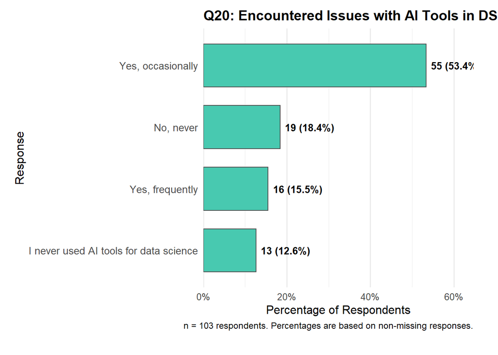

```r
# ---- 3) Horizontal bar chart with refined theme ----
p_q20 <- ggplot(Q20_summary, aes(
  y = fct_reorder(Response, Percent),
  x = Percent / 100   # convert percent back to proportion for plotting
)) +
  geom_bar(stat = "identity", fill = "#48C9B0", color = "gray30", width = 0.7) +

  # Inline labels showing count and percent
  geom_text(
    aes(label = paste0(Count, " (", round(Percent, 1), "%)")),
    hjust = -0.1, fontface = "bold", size = 3.6, color = "black"
  ) +

  # X-axis formatting
  scale_x_continuous(
    labels = label_percent(accuracy = 1),
    limits = c(0, max(Q20_summary$Percent / 100) + 0.1),
    expand = expansion(mult = c(0, 0.02))
  ) +

  # Titles and labels
  labs(
    title = "Q20: Encountered Issues with AI Tools in DS Tasks",
  #  subtitle = "Percentages based on valid respondents (one response per participant)",
    x = "Percentage of Respondents",
    y = "Response",
    caption = paste0("n = ", n_valid,
                     " respondents. Percentages are based on non-missing responses.")
  ) +

  # Match your publication-style theme
  theme_minimal(base_size = 12) +
  theme(
    panel.grid.major.y = element_blank(),
    axis.text.y = element_text(size = 10.5, lineheight = 1.1),
    plot.title = element_text(face = "bold", size = 14),
    plot.subtitle = element_text(size = 11),
    plot.caption = element_text(size = 9),
    plot.margin = margin(10, 25, 25, 15)
  )

# ---- 4) Save as high-resolution PNG ----
if (!dir.exists("Studnt_figs_10")) dir.create("Studnt_figs_10", recursive = TRUE)

ggsave(
  filename = "Studnt_figs_10/Q20_ai_tool_issues_horizontal_pub.png",
  plot = p_q20,
  dpi = 600,
  width = 8.5,
  height = 5.5,
  units = "in"
)

print(p_q20)
```

## Q21: Do you think AI tools can significantly enhance the following aspects of your data science workflow? (Strongly Disagree, Disagree, Neutral, Agree, Strongly Agree)

## q21 sorted

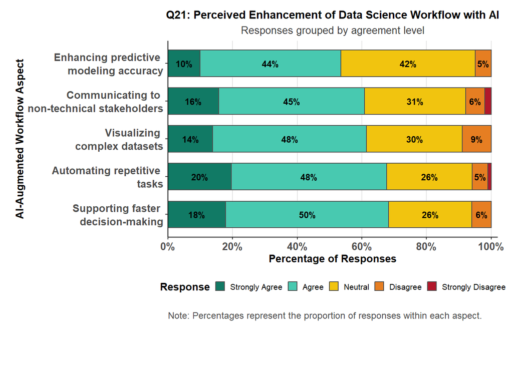

```r
# ---- 1) Define recode map ----
aspect_map_q21 <- c(
  Q21_1 = "Automating repetitive \ntasks",
  Q21_2 = "Enhancing predictive \nmodeling accuracy",
  Q21_3 = "Visualizing \ncomplex datasets",
  Q21_4 = "Supporting faster \ndecision-making",
  Q21_5 = "Communicating to \nnon-technical stakeholders"
)

# ---- 2) Define factor levels + consistent palette ----
levels_q21 <- c("Strongly Disagree", "Disagree", "Neutral", "Agree", "Strongly Agree")
pal_q21 <- c(
  "Strongly Disagree" = "#B2182B",  # deep red
  "Disagree"          = "#E67E22",  # orange
  "Neutral"           = "#F1C40F",  # gold
  "Agree"             = "#48C9B0",  # turquoise
  "Strongly Agree"    = "#117A65"   # teal green
)

# ---- 3) Reshape and clean ----
df_long_q21 <- FilteredDF %>%
  pivot_longer(
    cols = starts_with("Q21_"),
    names_to = "Item",
    values_to = "Response"
  ) %>%
  mutate(
    Aspect = recode(Item, !!!aspect_map_q21, .default = NA_character_),
    Response = factor(Response, levels = levels_q21)
  ) %>%
  filter(!is.na(Response), !is.na(Aspect))

# ---- 4) Calculate percentages ----
plot_df_q21 <- df_long_q21 %>%
  count(Aspect, Response, name = "n") %>%
  group_by(Aspect) %>%
  mutate(pct = n / sum(n)) %>%
  ungroup()

# ---- 5) Compute favorable % for sorting ----
plot_df_q21 <- plot_df_q21 %>%
  group_by(Aspect) %>%
  mutate(pct_fav = sum(pct[Response %in% c("Agree", "Strongly Agree")], na.rm = TRUE)) %>%
  ungroup() %>%
  mutate(Aspect = fct_reorder(Aspect, pct_fav, .desc = TRUE))

# ---- 6) Horizontal stacked bar chart ----
p_q21 <- ggplot(plot_df_q21, aes(y = Aspect, x = pct, fill = Response)) +
  geom_bar(stat = "identity", color = "gray30", width = 0.7) +

  # Inline percentage labels
  geom_text(
    aes(label = ifelse(pct > 0.04, paste0(round(pct * 100), "%"), "")),
    position = position_stack(vjust = 0.5),
    color = "black", size = 3, fontface = "bold"
  ) +

  # Format axes
  scale_x_continuous(
    labels = label_percent(accuracy = 1),
    limits = c(0, 1),
    breaks = seq(0, 1, 0.2),
    expand = expansion(mult = c(0, 0.02))
  ) +

  # Apply consistent color palette
  scale_fill_manual(values = pal_q21, guide = guide_legend(reverse = TRUE)) +

  # Titles and labels
  labs(
    title = "Q21: Perceived Enhancement of Data Science Workflow with AI",
    subtitle = "Responses grouped by agreement level",
    x = "Percentage of Responses",
    y = "AI-Augmented Workflow Aspect",
    fill = "Response",
    caption = "Note: Percentages represent the proportion of responses within each aspect."
  ) +

  # Apply publication theme
  theme_pub()

# ---- 7) Save as high-resolution PNG ----
ggsave(
  filename = "Studnt_figs_10/Q21_workflow_enhancement_horizontal_pub.png",
  plot = p_q21,
  dpi = 600,
  width = 9,
  height = 6,
  units = "in"
)

print(p_q21)
```

## Q22: What concerns or challenges do you face when integrating AI tools into your data science workflow?

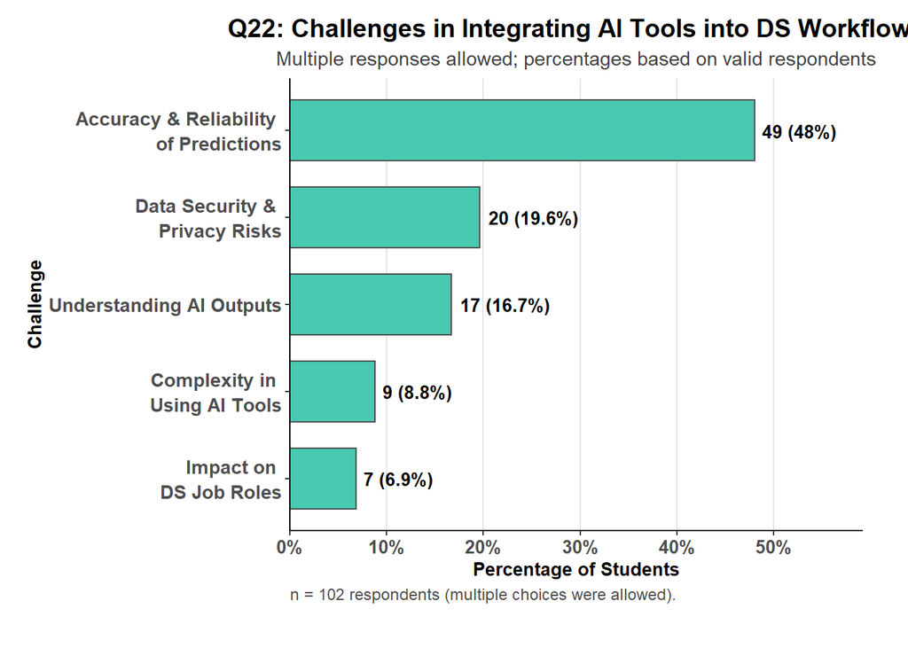

```r
library(dplyr)
library(stringr)
library(forcats)
library(ggplot2)
library(scales)

# ---- 1) Create binary indicators for each challenge ----
FilteredDF <- FilteredDF %>%
  mutate(
    q22_complexity    = str_detect(Q22, regex("complexity", ignore_case = TRUE)),
    q22_accuracy      = str_detect(Q22, regex("accuracy", ignore_case = TRUE)),
    q22_understanding = str_detect(Q22, regex("understanding", ignore_case = TRUE)),
    q22_privacy       = str_detect(Q22, regex("privacy", ignore_case = TRUE)),
    q22_jobimpact     = str_detect(Q22, regex("job", ignore_case = TRUE))
  )


# ---- 2) Summarize counts ----
q22_summary <- tibble(
  Concern = c(
    "Complexity in \nUsing AI Tools",
    "Accuracy & Reliability \nof Predictions",
    "Understanding AI Outputs",
    "Data Security & \nPrivacy Risks",
    "Impact on \nDS Job Roles"
  ),
  Count = c(
    sum(FilteredDF$q22_complexity, na.rm = TRUE),
    sum(FilteredDF$q22_accuracy, na.rm = TRUE),
    sum(FilteredDF$q22_understanding, na.rm = TRUE),
    sum(FilteredDF$q22_privacy, na.rm = TRUE),
    sum(FilteredDF$q22_jobimpact, na.rm = TRUE)
  )
)

# ---- 3) Add percentages ----
n22 <- sum(!is.na(FilteredDF$Q22))  # total number of valid respondents

q22_summary <- q22_summary %>%
  mutate(
    Percent = Count / n22,
    Label = paste0(Count, " (", round(Percent * 100, 1), "%)")
  )

# ---- 4) Horizontal bar chart with refined theme ----
p_q22 <- ggplot(q22_summary, aes(
  y = fct_reorder(Concern, Percent),
  x = Percent
)) +
  geom_bar(stat = "identity", fill = "#48C9B0", color = "gray30", width = 0.7) +

  # Inline labels: counts + percents
  geom_text(
    aes(label = Label),
    hjust = -0.1, fontface = "bold", size = 3.6, color = "black"
  ) +

  # X-axis formatting
  scale_x_continuous(
    labels = label_percent(accuracy = 1),
    limits = c(0, max(q22_summary$Percent) + 0.1),
    expand = expansion(mult = c(0, 0.02))
  ) +

  # Titles & caption
  labs(
    title = "Q22: Challenges in Integrating AI Tools into DS Workflows",
    subtitle = "Multiple responses allowed; percentages based on valid respondents",
    x = "Percentage of Students",
    y = "Challenge",
    caption = paste0(
      "n = ", n22,
      " respondents (multiple choices were allowed)."
    )
  ) +

  # Publication theme
  theme_pub() +
  theme(
    panel.grid.major.y = element_blank(),
    axis.text.y = element_text(size = 10.5, lineheight = 1.1),
    plot.title = element_text(face = "bold", size = 14),
    plot.subtitle = element_text(size = 11),
    plot.caption = element_text(size = 9),
    plot.margin = margin(10, 25, 25, 15)
  )

# ---- 5) Save as high-resolution PNG ----
if (!dir.exists("Studnt_figs_10")) dir.create("Studnt_figs_10", recursive = TRUE)

ggsave(
  filename = "Studnt_figs_10/Q22_challenges_workflow_pub.png",
  plot = p_q22,
  dpi = 600,
  width = 8.5,
  height = 5.5,
  units = "in"
)

# ---- 6) View table and plot ----
print(p_q22)
```

```r
q22_summary
```

```
## # A tibble: 5 × 4
##   Concern                                   Count Percent Label
##   <chr>                                     <int>   <dbl> <chr>
## 1 "Complexity in \nUsing AI Tools"              9  0.0882 9 (8.8%)
## 2 "Accuracy & Reliability \nof Predictions"    49  0.480  49 (48%)
## 3 "Understanding AI Outputs"                   17  0.167  17 (16.7%)
## 4 "Data Security & \nPrivacy Risks"            20  0.196  20 (19.6%)
## 5 "Impact on \nDS Job Roles"                    7  0.0686 7 (6.9%)
```

## Q23: What concerns do you have about integrating AI tools into education in general?

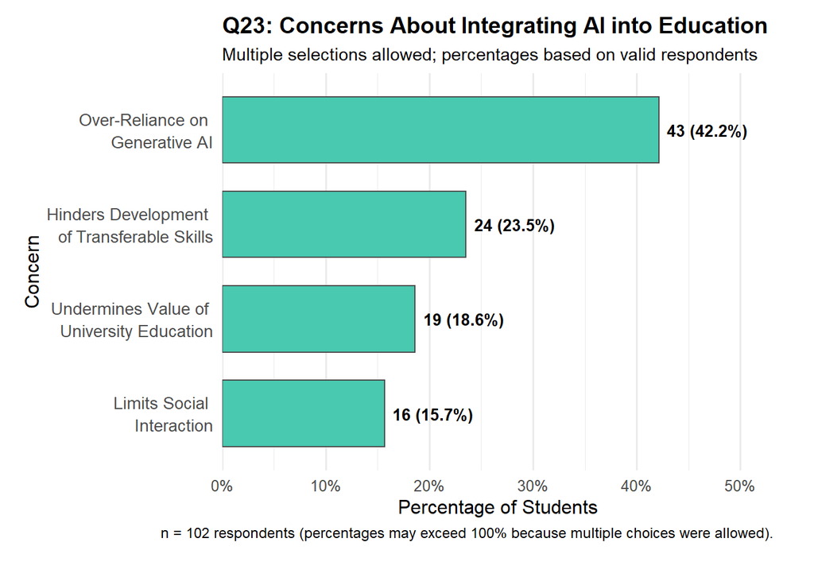

```r
# ---- 1) Create binary indicators for each concern ----
FilteredDF <- FilteredDF %>%
  mutate(
    q23_undermines_value = str_detect(Q23, regex("undermine|value", ignore_case = TRUE)),
    q23_limits_social    = str_detect(Q23, regex("interact|social", ignore_case = TRUE)),
    q23_hinders_skills   = str_detect(Q23, regex("skills|teamwork|problem", ignore_case = TRUE)),
    q23_overreliance     = str_detect(Q23, regex("over[- ]?reliant", ignore_case = TRUE))
  )

# ---- 2) Summarize counts ----
q23_summary <- tibble(
  Concern = c(
    "Undermines Value of \nUniversity Education",
    "Limits Social \nInteraction",
    "Hinders Development \nof Transferable Skills",
    "Over-Reliance on \nGenerative AI"
  ),
  Count = c(
    sum(FilteredDF$q23_undermines_value, na.rm = TRUE),
    sum(FilteredDF$q23_limits_social, na.rm = TRUE),
    sum(FilteredDF$q23_hinders_skills, na.rm = TRUE),
    sum(FilteredDF$q23_overreliance, na.rm = TRUE)
  )
)

# ---- 3) Add percentages ----
n_valid <- nrow(FilteredDF %>% filter(!is.na(Q23))) # or replace with total respondents

q23_summary <- q23_summary %>%
  mutate(
    Percent = Count / n_valid,
    Label = paste0(Count, " (", round(Percent * 100, 1), "%)")
  )

# ---- 4) Horizontal bar chart with refined theme ----
p_q23 <- ggplot(q23_summary, aes(
  y = fct_reorder(Concern, Percent),
  x = Percent
)) +
  geom_bar(stat = "identity", fill = "#48C9B0", color = "gray30", width = 0.7) +

  # Inline count + percent labels
  geom_text(
    aes(label = Label),
    hjust = -0.1, fontface = "bold", size = 3.6, color = "black"
  ) +

  # X-axis formatting
  scale_x_continuous(
    labels = label_percent(accuracy = 1),
    limits = c(0, max(q23_summary$Percent) + 0.1),
    expand = expansion(mult = c(0, 0.02))
  ) +

  # Titles and captions
  labs(
    title = "Q23: Concerns About Integrating AI into Education",
    subtitle = "Multiple selections allowed; percentages based on valid respondents",
    x = "Percentage of Students",
    y = "Concern",
    caption = paste0(
      "n = ", n_valid,
      " respondents (percentages may exceed 100% because multiple choices were allowed)."
    )
  ) +

  # Publication-style theme
  theme_minimal(base_size = 12) +
  theme(
    panel.grid.major.y = element_blank(),
    axis.text.y = element_text(size = 10.5, lineheight = 1.1),
    plot.title = element_text(face = "bold", size = 14),
    plot.subtitle = element_text(size = 11),
    plot.caption = element_text(size = 9),
    plot.margin = margin(10, 25, 25, 15)
  )

# ---- 5) Save plot ----


ggsave(
  filename = "Studnt_figs_10/Q23_ai_concerns_horizontal_pub.png",
  plot = p_q23,
  dpi = 600,
  width = 8.5,
  height = 5.5,
  units = "in"
)

print(p_q23)
```

##Q23 pub SKIP Did not look good

```r
# # Example for Q7
# result_q23<- plot_multi_response(
#   data = FilteredDF,
#   col = Q23,
#   title = "Q23: Concerns About Integrating AI into Education",
#   xlab = "Percentage of Respondents",
#   ylab = "Concern"
# )
#
# print(result_q23)
```

## Q24: Do you believe that AI tools should complement traditional methods in data science, or replace them?

## Q24 horizontal

```r
library(dplyr)
library(ggplot2)
library(scales)
library(forcats)
library(stringr)


# ---- 1) Wrap labels for readability ----
FilteredDF$Q24 <- str_wrap(FilteredDF$Q24, width = 35)

# ---- 2) Split and tidy multi-response data ----
long_q24 <- FilteredDF %>%
  select(Q24) %>%
  filter(!is.na(Q24)) %>%
  mutate(Q24 = str_split(Q24, ",")) %>%
  unnest(Q24) %>%
  mutate(Q24 = str_trim(Q24))

# ---- 3) Compute counts and % of valid respondents ----
n_valid <- nrow(FilteredDF %>% filter(!is.na(Q24)))   # number of respondents who answered Q24

plot_df_q24 <- long_q24 %>%
  count(Q24, name = "Count") %>%
  mutate(
    Percent = Count / n_valid,
    Label = paste0(Count, " (", round(Percent * 100, 1), "%)")
  )

# ---- 4) Horizontal bar chart (publication style) ----
p_q24 <- ggplot(plot_df_q24, aes(
  y = fct_reorder(Q24, Percent),
  x = Percent
)) +
  geom_bar(stat = "identity", fill = "#48C9B0", color = "gray30", width = 0.7) +

  # Inline labels: count + percent
  geom_text(
    aes(label = Label),
    hjust = -0.1, fontface = "bold", size = 3.6, color = "black"
  ) +

  # X-axis formatting
  scale_x_continuous(
    labels = label_percent(accuracy = 1),
    limits = c(0, max(plot_df_q24$Percent) + 0.2),
    expand = expansion(mult = c(0, 0.02))
  ) +

  # Titles and captions
  labs(
    title = "Q24: Should AI Tools Complement or \nReplace Traditional Methods?",
    # subtitle = "Multiple selections allowed; \npercentages based on valid respondents",
    x = "Percentage of Respondents",
    y = "Response",
  #   caption = paste0(
  #     "n = ", n_valid,
  #     " respondents."
  #   )
  # ) +

   caption = paste0(
      "n = ", n_valid,
      " respondents (percentages may exceed 100% because multiple choices were allowed).")
    )+
  # Publication theme
  theme_minimal(base_size = 12) +
  theme(
    panel.grid.major.y = element_blank(),
    axis.text.y = element_text(size = 10.5, lineheight = 1.1),
    plot.title = element_text(face = "bold", size = 14),
    plot.subtitle = element_text(size = 11),
    plot.caption = element_text(size = 9),
    plot.margin = margin(10, 25, 25, 15)
  )

# ---- 5) Save high-resolution figure ----
if (!dir.exists("Studnt_figs_10")) dir.create("Studnt_figs_10", recursive = TRUE)

ggsave(
  filename = "Studnt_figs_10/Q24_complement_or_replace_horizontal_pub.png",
  plot = p_q24,
  dpi = 600,
  width = 8.5,
  height = 5.5,
  units = "in"
)

# ---- 6) Output summary table ----
plot_df_q24
```

```
## # A tibble: 5 × 4
##   Q24                                                        Count Percent Label
##   <chr>                                                      <int>   <dbl> <chr>
## 1 "AI tools complement traditional\nmethods"                    32  0.314  32 (…
## 2 "AI tools do not complement\ntraditional data science too…     6  0.0588 6 (5…
## 3 "AI tools mostly replace traditional\nmethods"                 6  0.0588 6 (5…
## 4 "Balance between AI tools and\ntraditional methods"           56  0.549  56 (…
## 5 "Rely entirely on AI tools"                                    2  0.0196 2 (2…
```

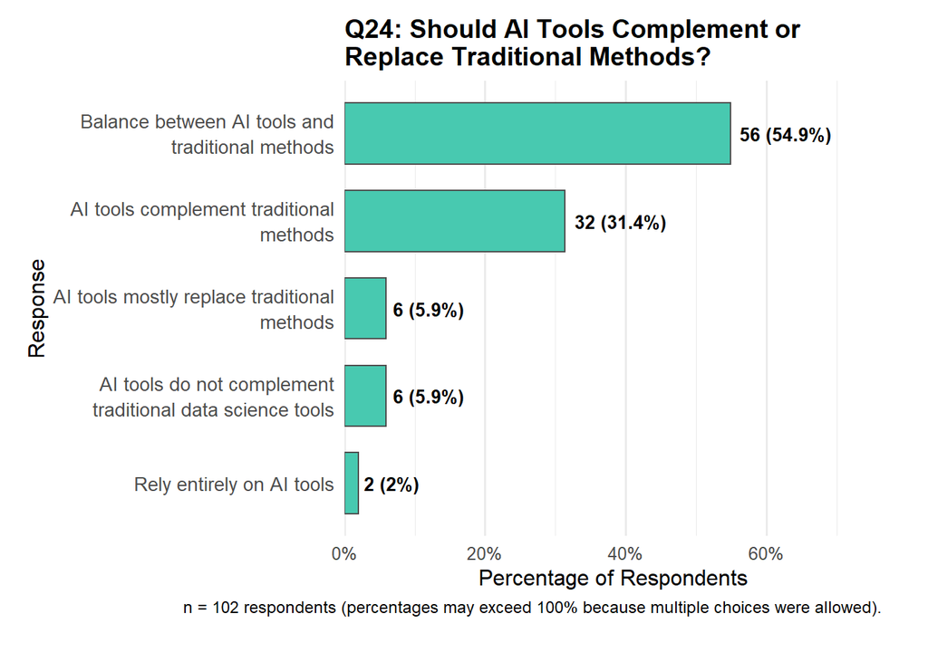

```r
print(p_q24)
```

#